# 03_betts-hf

betts

2024-10-06

# 2024.október 6. - Ökönometria házi feladat 2. - wms management survey

## 0.lépés - Előkészítés/Adattisztítás

### Az adatok megtisztításához és rendezéséhez szükséges lépések véghezvitele, mint a fájl hely beállítása, a packagek betöltése, az adatok beolvasása és betöltése.

```r
setwd("~/Documents/Documents - betts’s MacBook Air/rajk/kurzusok/3.félév/ökonometria/hf -3")

#install.packages("broom")
#install.packages("cowplot")

library(tidyverse)
library(dplyr)
library(scales)
library(xtable)
library(modelsummary)
library(ggthemes)
library(extrafont)
library(cowplot)
library(broom)
library(corrplot)
library(gridExtra)
library(tidyr)

wms_data <- read.csv("wms_da_textbook.csv")
```

### A country oszlopból előhívtam a változókat és azok alapján kiválasztottam Szingapúrt, mint célország és egy új adattáblába kiszűrtem ezeket, és mivel az összes adatom 2012-re szól, ezért nem szűrtem tovább.

```r
print(unique(wms_data$country))
```

```
##  [1] "United States"       "India"               "New Zealand"
##  [4] "Australia"           "Argentina"           "Brazil"
##  [7] "Canada"              "Chile"               "China"
## [10] "Germany"             "Spain"               "France"
## [13] "Northern Ireland"    "Great Britain"       "Greece"
## [16] "Republic of Ireland" "Italy"               "Japan"
## [19] "Mexico"              "Poland"              "Portugal"
## [22] "Sweden"              "Singapore"           "Turkey"
```

```r
singapore_data <- wms_data%>%
  filter(country=="Singapore")
```

### Az adattáblában szerepelt közel 200 olyan változó, amit nem fogok használni az elemzésem során, emiatt kivettem őket, hogy későbbiekben könnyebb legyen az adattáblát értelmezni.

```r
singapore_data <- singapore_data[, -c(41:245)]
```

### Megnéztem, hogy az adattáblában szerepel-e olyan hiányzó adat, ami az emp_firm vagy a management változó oszlopait érinti. Mivel az emp_firm oszlopban szerepeltek N/A értékek, ezért kiszedtem azokat a megfigyeléseket, amelyeknél az emp_firm oszlopban N/A adat szerepelt, hogy a későbbi elemzés során már a tiszta adatokat tudjam vizsgálni.

```r
any(is.na(singapore_data))
```

```
## [1] TRUE
```

```r
colSums(is.na(singapore_data))
```

```
##      firmid        wave         cty     country         sic  management
##           0           0           0           0           0           0
##  operations     monitor      target      people       lean1       lean2
##           0           0           0           0           0           0
##       perf1       perf2       perf3       perf4       perf5       perf6
##           0           0           0           0           0           0
##       perf7       perf8       perf9      perf10     talent1     talent2
##           0           0           0           0           0           0
##     talent3     talent4     talent5     talent6    emp_firm     firmage
##           0           0           0           0          13         235
##   ownership      mne_yn     mne_cty competition      export    degree_m
##           0           0           0           0          14          67
##   degree_nm    degree_t i_seniority reliability
##          70          93           6           1
```

```r
singapore_data <- singapore_data[complete.cases(singapore_data[, c("emp_firm")]), ]

colSums(is.na(singapore_data))
```

```
##      firmid        wave         cty     country         sic  management
##           0           0           0           0           0           0
##  operations     monitor      target      people       lean1       lean2
##           0           0           0           0           0           0
##       perf1       perf2       perf3       perf4       perf5       perf6
##           0           0           0           0           0           0
##       perf7       perf8       perf9      perf10     talent1     talent2
##           0           0           0           0           0           0
##     talent3     talent4     talent5     talent6    emp_firm     firmage
##           0           0           0           0           0         228
##   ownership      mne_yn     mne_cty competition      export    degree_m
##           0           0           0           0          12          62
##   degree_nm    degree_t i_seniority reliability
##          66          88           6           1
```

## 1.lépés - Főkomponens elemzés

### A főkomponens elemzés előkészítéséhez létrehoztam egy adattáblát, amelyben csak az a 18 változóm szerepel, amelyek szükségesek lesznek a főkomponens létrehozásához.

```r
pca_data <- singapore_data %>%
  select(where(is.numeric))


pca_data <- pca_data[, c(9:26)]
```

### A pca_table adattáblámon végrehajtom a főkomponens analízist a prcomp paranccsal.

```r
pca_table <- pca_data %>%
  prcomp(scale = TRUE)

summary(pca_table)
```

```
## Importance of components:
##                           PC1     PC2     PC3     PC4     PC5     PC6     PC7
## Standard deviation     2.8700 1.09467 1.04393 0.96408 0.90814 0.87954 0.82997
## Proportion of Variance 0.4576 0.06657 0.06054 0.05164 0.04582 0.04298 0.03827
## Cumulative Proportion  0.4576 0.52418 0.58472 0.63636 0.68218 0.72516 0.76343
##                            PC8     PC9   PC10   PC11    PC12    PC13    PC14
## Standard deviation     0.79307 0.74360 0.7263 0.7010 0.68469 0.63413 0.56939
## Proportion of Variance 0.03494 0.03072 0.0293 0.0273 0.02604 0.02234 0.01801
## Cumulative Proportion  0.79837 0.82909 0.8584 0.8857 0.91174 0.93408 0.95209
##                           PC15    PC16    PC17    PC18
## Standard deviation     0.55825 0.50783 0.41373 0.34888
## Proportion of Variance 0.01731 0.01433 0.00951 0.00676
## Cumulative Proportion  0.96940 0.98373 0.99324 1.00000
```

### Miután létrehoztam a főkomponenseimet, az első (PC1) értékeknek létrehozok egy oszlopot a singapore_data adathalmazomban.

```r
singapore_data$PC1 <- pca_table$x[, 1]
```

## 2.lépés - Rotation matrix

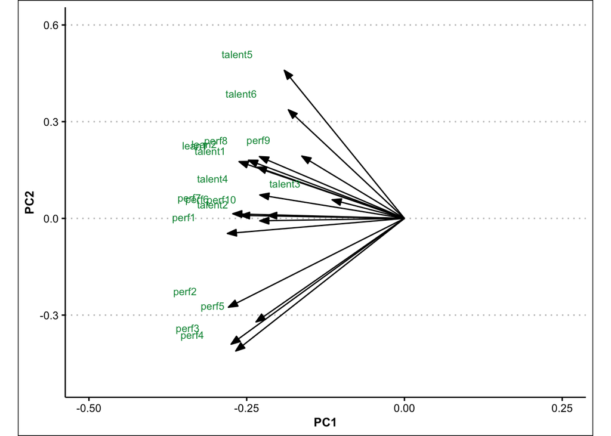

```r
pca_table %>%
  tidy(matrix = "rotation") %>%
  pivot_wider(names_from = "PC", names_prefix = "PC", values_from = "value") %>%
  ggplot(aes(PC1, PC2)) +
  geom_segment(xend = 0, yend = 0,
               arrow = arrow(angle = 20, ends = "first", type = "closed", length = grid::unit(8, "pt"))) +
  geom_text(
    aes(label = column),
    hjust = 1, nudge_x = -0.05, nudge_y = 0.05,
    color = "#049445", size = 3
  ) +
  xlim(-0.5, 0.25) + ylim(-0.5, 0.6) +
  theme_clean(12) +
  theme(aspect.ratio = 3/4) +
   theme(text = element_text(family = "Arial"),
    axis.title.x = element_text(face = "bold"),
    axis.title.y = element_text(face = "bold"))
```

```r
pca_table %>% tidy(matrix="eigenvalues")
```

```
## # A tibble: 18 × 4
##       PC std.dev percent cumulative
##    <dbl>   <dbl>   <dbl>      <dbl>
##  1     1   2.87  0.458        0.458
##  2     2   1.09  0.0666       0.524
##  3     3   1.04  0.0605       0.585
##  4     4   0.964 0.0516       0.636
##  5     5   0.908 0.0458       0.682
##  6     6   0.880 0.0430       0.725
##  7     7   0.830 0.0383       0.763
##  8     8   0.793 0.0349       0.798
##  9     9   0.744 0.0307       0.829
## 10    10   0.726 0.0293       0.858
## 11    11   0.701 0.0273       0.886
## 12    12   0.685 0.0260       0.912
## 13    13   0.634 0.0223       0.934
## 14    14   0.569 0.0180       0.952
## 15    15   0.558 0.0173       0.969
## 16    16   0.508 0.0143       0.984
## 17    17   0.414 0.00951      0.993
## 18    18   0.349 0.00676      1
```

[figure not shown]

```r
pca_table %>%
  tidy(matrix = "eigenvalues") %>%
  ggplot(aes(PC, percent)) +
  geom_col(color="#0b4d29", fill = "#049445", alpha = 0.7) +
  labs(title = "PC értékek százalékos aránya", x = "Százalék", y = "PC") +
  scale_x_continuous(breaks = 1:18) +
  scale_y_continuous(
    labels = scales::percent_format(),
    expand = expansion(mult = c(0, 0.01))) +
  theme_clean(16) +
  theme(text = element_text(family = "Arial"),
    axis.title.x = element_text(face = "bold"),
    axis.title.y = element_text(face = "bold"))
```

## 3.lépés - A főkomponens analízis értelmezéséhez létrehoztam rekesz-pontdiagramokat és pontdiagramokat, hogy könnyebben lehessen értelmezni a kapott adatokat. A főkomponens és a válllatvezetési pontszám kapcsolatán keresztül vizsgálva.

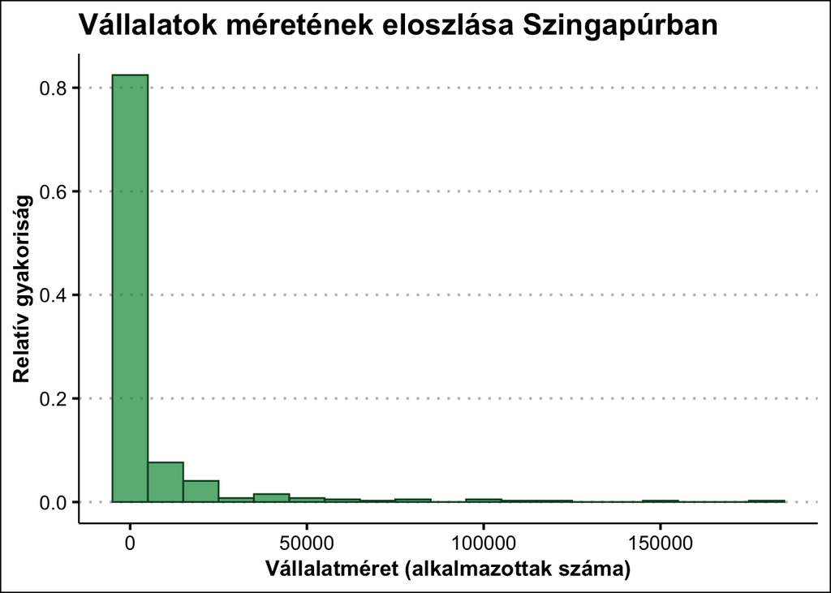

```r
ggplot(singapore_data, aes(emp_firm)) +
  geom_histogram(aes(y=after_stat(count / sum(count))), binwidth = 10000, color="#0b4d29", fill="#049445", alpha = 0.7) +
  labs(title = "Vállalatok méretének eloszlása Szingapúrban", x="Vállalatméret (alkalmazottak száma)", y="Relatív gyakoriság") +
  theme_clean(16) +
  theme(text = element_text(family = "Arial"),
    axis.title.x = element_text(face = "bold"),
    axis.title.y = element_text(face = "bold"))
```

```r
singapore_data <- singapore_data %>%
  mutate(ln_emp_firm = log(emp_firm))
```

[figure not shown]

```r
singapore_data %>%
  ggplot(aes(ln_emp_firm)) +
  geom_histogram(aes(y = after_stat(count / sum(count))), binwidth = 0.3, color = "#0b4d29", fill = "#049445", alpha = 0.7) +
  labs(title = "Vállalatok méretének eloszlása Szingapúrban",
       x = "Vállalat mérete (alkalmazottak száma)",
       y = "Relatív gyakoriság") +
  theme_clean(16) +
  theme(text = element_text(family = "Arial"),
    axis.title.x = element_text(face = "bold"),
    axis.title.y = element_text(face = "bold"))
```

```r
range(singapore_data$ln_emp_firm, na.rm = TRUE)
```

```
## [1]  3.688879 12.078239
```

```r
range(singapore_data$PC1, na.rm = TRUE)
```

```
## [1] -7.797259  7.302910
```

```r
range(singapore_data$management, na.rm = TRUE)
```

```
## [1] 1.222222 4.833333
```

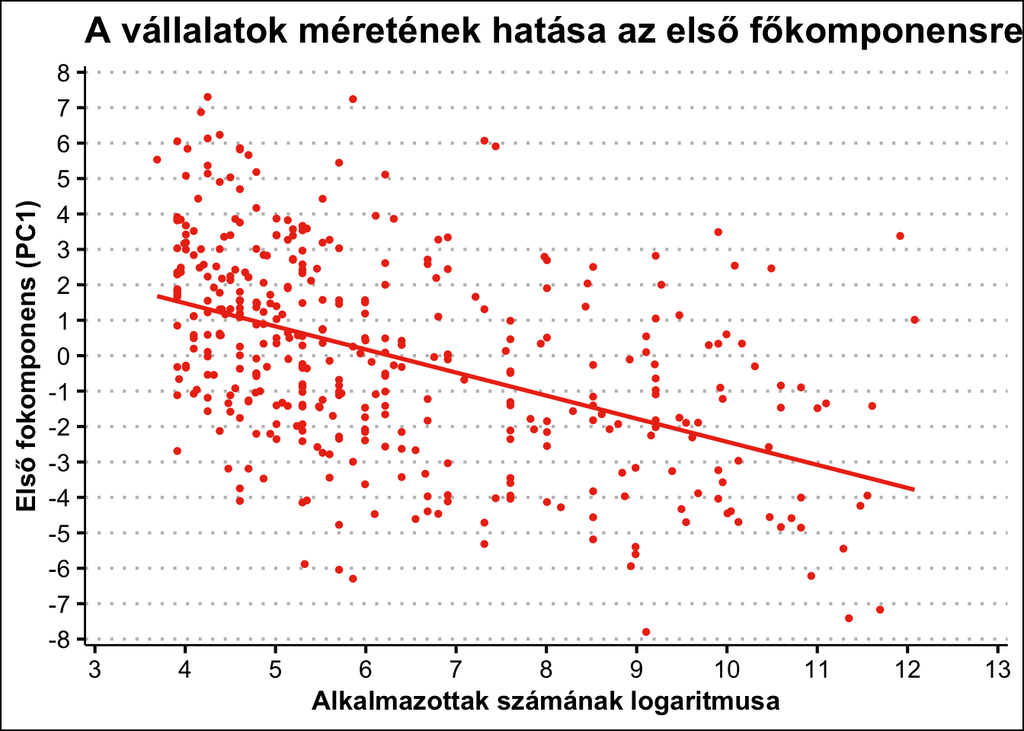

```r
ggplot(singapore_data, aes(x = ln_emp_firm, y = PC1)) +
  geom_point(color = "#ed3615", size = 1.5,  shape = 16, show.legend=FALSE, na.rm = TRUE) +
  geom_smooth(method = "lm", se = FALSE, linetype = "solid", color = "#ed3615") +
  scale_x_continuous(expand = c(0.01,0.01),limits=c(3, 13), breaks=seq(3, 13, by=1)) +
  scale_y_continuous(expand = c(0.01,0.01),limits = c(-8, 8), breaks = seq(-8, 8,1)) +
  labs(title = "A vállalatok méretének hatása az első főkomponensre", x = "Alkalmazottak számának logaritmusa", y = "Első fokomponens (PC1)")+
  theme_clean(16) +
  theme(text = element_text(family = "Arial"),
    axis.title.x = element_text(face = "bold"),
    axis.title.y = element_text(face = "bold"))
```